# BestPlaceCA

Jiahui Tang  
2017-12-01

```r
library(httr)
library(glue)
library(rvest)
library(stringr)
library(tidyverse)
library(reshape)
library(ggplot2)
```

## Scrape data

Work through the final set of slides from the rOpenSci UseR! 2016 workshop. This will give you basic orientation, skills, and pointers on the rvest package.

Scrape a multi-record dataset off the web! Convert it into a clean and tidy data frame. Store that as a file ready for (hypothetical!) downstream analysis. Do just enough basic exploration of the resulting data, possibly including some plots, that you and a reader are convinced you’ve successfully downloaded and cleaned it.

## About this project

*This project is one homework for [STAT547](http://stat545.com/index.html)*

I followed the tutorial of @ropensci and scraped some data about the Cost-of-Living and Job of Counties in California. I used some functions like read_html(), html_nodes() and html_attr() to get useful data without using API.

The website that I extracted is [bestplaces](https://www.bestplaces.net).

## Display data and plots

```r
CA_cost <- read_csv("./CA_cost.csv")
CA_job <- read_csv("./CA_job.csv")
```

I scraped some data and created two data.frame for them, namely CA_job and CA_cost. The detailed informations are shown below.

```r
knitr::kable(CA_job)
```

| Counties | IncomePerCap | HouseholdIncome | UnemploymentRate | RecentJobGrowth | FutureJobGrowth |
| --- | --- | --- | --- | --- | --- |
| United States | 28555 | 53482 | 5.2 | 1.59 | 37.98 |
| Alameda | 36439 | 73775 | 4.7 | 2.62 | 40.53 |
| Alpine | 24375 | 61343 | 7.6 | 1.70 | 35.80 |
| Amador | 27373 | 52964 | 6.1 | 1.60 | 37.10 |
| Butte | 24430 | 43165 | 7.2 | 1.45 | 35.71 |
| Calaveras | 29296 | 54936 | 6.0 | 2.92 | 39.85 |
| Colusa | 22211 | 50503 | 13.7 | 2.84 | 31.99 |
| Contra Costa | 38770 | 79799 | 4.9 | 2.56 | 40.23 |
| Del Norte | 19424 | 39302 | 7.4 | 0.86 | 34.31 |
| El Dorado | 35128 | 68507 | 5.4 | 2.19 | 38.99 |
| Fresno | 20231 | 45201 | 9.4 | 2.33 | 35.25 |
| Glenn | 21698 | 40106 | 8.6 | 3.98 | 39.36 |
| Humboldt | 23516 | 42153 | 5.2 | 0.94 | 36.68 |
| Imperial | 16409 | 41772 | 23.7 | 0.25 | 16.80 |
| Inyo | 27028 | 45625 | 5.3 | 0.13 | 34.95 |
| Kern | 20467 | 48574 | 10.8 | -0.06 | 29.07 |
| Kings | 18518 | 47341 | 10.2 | 2.62 | 35.04 |
| Lake | 21310 | 35997 | 6.7 | 0.30 | 33.90 |
| Lassen | 19847 | 53351 | 6.7 | 2.09 | 37.49 |
| Los Angeles | 27987 | 55870 | 5.2 | 1.37 | 37.55 |
| Madera | 17797 | 45490 | 9.4 | -1.82 | 26.97 |
| Marin | 58004 | 91529 | 3.5 | 1.84 | 40.17 |
| Mariposa | 28327 | 50560 | 5.8 | 1.02 | 36.25 |
| Mendocino | 23712 | 43290 | 5.1 | 0.19 | 35.27 |
| Merced | 18464 | 43066 | 10.6 | 1.77 | 32.94 |
| Modoc | 21830 | 38560 | 7.2 | -1.65 | 29.51 |
| Mono | 29578 | 61814 | 5.9 | 1.53 | 37.16 |
| Monterey | 25048 | 58582 | 6.2 | 2.15 | 38.11 |
| Napa | 35092 | 70925 | 4.2 | 2.36 | 40.51 |
| Nevada | 32117 | 56949 | 5.0 | 1.82 | 38.64 |
| Orange | 34416 | 75998 | 4.4 | 2.26 | 40.13 |
| Placer | 35711 | 73747 | 4.8 | 2.25 | 39.70 |
| Plumas | 29167 | 48032 | 8.3 | -1.18 | 29.34 |
| Riverside | 23660 | 56592 | 6.7 | 3.40 | 40.10 |
| Sacramento | 27071 | 55615 | 5.9 | 2.27 | 38.64 |
| San Benito | 26317 | 67874 | 6.9 | 3.32 | 39.74 |
| San Bernardino | 21384 | 54100 | 6.4 | 3.44 | 40.49 |
| San Diego | 31043 | 63996 | 5.1 | 2.22 | 39.34 |
| San Francisco | 49986 | 78378 | 3.5 | 3.85 | 44.19 |
| San Joaquin | 22642 | 53253 | 8.3 | 2.82 | 37.35 |
| San Luis Obispo | 30392 | 59454 | 4.5 | 2.58 | 40.66 |
| San Mateo | 47198 | 91421 | 3.3 | 3.79 | 44.29 |
| Santa Barbara | 30526 | 63409 | 4.9 | 1.30 | 37.70 |
| Santa Clara | 42666 | 93854 | 4.1 | 3.34 | 42.59 |
| Santa Cruz | 33050 | 66923 | 6.3 | 2.14 | 37.98 |
| Shasta | 23763 | 44556 | 7.2 | 1.38 | 35.56 |
| Sierra | 28030 | 43107 | 7.4 | -3.76 | 25.09 |
| Siskiyou | 22482 | 37495 | 7.5 | 1.65 | 35.80 |
| Solano | 29132 | 67341 | 5.9 | 2.81 | 39.72 |
| Sonoma | 33361 | 63799 | 4.2 | 2.24 | 40.28 |
| Stanislaus | 21729 | 49573 | 9.2 | 2.16 | 35.12 |
| Sutter | 23828 | 51527 | 9.8 | 2.77 | 35.74 |
| Tehama | 21002 | 42369 | 7.8 | 1.66 | 35.51 |
| Trinity | 23145 | 36862 | 6.4 | 2.10 | 37.80 |
| Tulare | 17888 | 42863 | 10.8 | 3.75 | 36.70 |
| Tuolumne | 26063 | 48493 | 6.4 | 1.30 | 36.20 |
| Ventura | 33308 | 77335 | 5.4 | 0.36 | 35.31 |
| Yolo | 28080 | 55508 | 5.9 | 2.21 | 38.52 |
| Yuba | 19586 | 45470 | 8.8 | 2.48 | 36.17 |

```r
knitr::kable(CA_cost)
```

| Counties | Overall | Grocery | Health | Housing | Utilities | Transportation | Miscellaneous |
| --- | --- | --- | --- | --- | --- | --- | --- |
| United States | 100 | 100.0 | 100 | 100 | 100 | 100 | 100 |
| Alameda | 202 | 118.4 | 112 | 396 | 96 | 106 | 110 |
| Alpine | 131 | 102.6 | 114 | 186 | 92 | 106 | 105 |
| Amador | 119 | 102.6 | 114 | 148 | 92 | 106 | 105 |
| Butte | 112 | 101.5 | 105 | 134 | 94 | 105 | 99 |
| Calaveras | 118 | 102.6 | 114 | 145 | 92 | 106 | 105 |
| Colusa | 105 | 102.6 | 114 | 104 | 92 | 106 | 105 |
| Contra Costa | 168 | 118.5 | 111 | 289 | 95 | 107 | 112 |
| Del Norte | 104 | 100.4 | 107 | 112 | 96 | 105 | 97 |
| El Dorado | 141 | 110.0 | 108 | 211 | 111 | 112 | 102 |
| Fresno | 108 | 105.0 | 105 | 110 | 121 | 111 | 104 |
| Glenn | 114 | 102.6 | 114 | 133 | 92 | 106 | 105 |
| Humboldt | 116 | 99.6 | 106 | 146 | 95 | 107 | 99 |
| Imperial | 100 | 99.8 | 105 | 98 | 95 | 107 | 98 |
| Inyo | 117 | 100.2 | 107 | 151 | 93 | 107 | 97 |
| Kern | 102 | 101.2 | 106 | 98 | 112 | 108 | 101 |
| Kings | 98 | 101.4 | 106 | 91 | 94 | 107 | 98 |
| Lake | 114 | 116.1 | 114 | 115 | 99 | 111 | 115 |
| Lassen | 96 | 101.3 | 105 | 84 | 95 | 107 | 97 |
| Los Angeles | 156 | 95.5 | 93 | 283 | 110 | 102 | 91 |
| Madera | 104 | 100.3 | 105 | 110 | 94 | 107 | 98 |
| Marin | 248 | 118.5 | 111 | 539 | 95 | 107 | 112 |
| Mariposa | 111 | 102.6 | 114 | 125 | 92 | 106 | 105 |
| Mendocino | 138 | 116.8 | 114 | 192 | 98 | 111 | 114 |
| Merced | 104 | 99.8 | 107 | 111 | 95 | 106 | 97 |
| Modoc | 102 | 102.6 | 114 | 97 | 92 | 106 | 105 |
| Mono | 133 | 102.6 | 114 | 192 | 92 | 106 | 105 |
| Monterey | 148 | 100.4 | 107 | 250 | 95 | 105 | 96 |
| Napa | 175 | 116.6 | 116 | 308 | 100 | 112 | 114 |
| Nevada | 151 | 138.3 | 114 | 206 | 125 | 120 | 126 |
| Orange | 187 | 106.3 | 108 | 356 | 110 | 113 | 104 |
| Placer | 145 | 110.0 | 108 | 224 | 111 | 112 | 102 |
| Plumas | 110 | 102.6 | 114 | 121 | 92 | 106 | 105 |
| Riverside | 126 | 108.3 | 100 | 173 | 110 | 110 | 98 |
| Sacramento | 127 | 111.8 | 108 | 167 | 114 | 108 | 103 |
| San Benito | 160 | 117.0 | 116 | 263 | 127 | 110 | 104 |
| San Bernardino | 121 | 108.0 | 103 | 153 | 107 | 113 | 100 |
| San Diego | 160 | 106.8 | 111 | 273 | 101 | 112 | 103 |
| San Francisco | 275 | 121.6 | 115 | 610 | 96 | 115 | 119 |
| San Joaquin | 122 | 105.1 | 110 | 156 | 98 | 108 | 105 |
| San Luis Obispo | 162 | 101.0 | 105 | 292 | 94 | 107 | 97 |
| San Mateo | 258 | 118.5 | 111 | 571 | 95 | 107 | 112 |
| Santa Barbara | 164 | 101.9 | 105 | 297 | 95 | 106 | 97 |
| Santa Clara | 242 | 120.4 | 114 | 515 | 128 | 112 | 105 |
| Santa Cruz | 194 | 101.1 | 105 | 391 | 93 | 105 | 97 |
| Shasta | 107 | 99.7 | 107 | 119 | 94 | 106 | 98 |
| Sierra | 110 | 102.6 | 114 | 121 | 92 | 106 | 105 |
| Siskiyou | 98 | 102.6 | 114 | 83 | 92 | 106 | 105 |
| Solano | 139 | 116.2 | 114 | 193 | 99 | 112 | 114 |
| Sonoma | 171 | 117.6 | 116 | 293 | 100 | 111 | 114 |
| Stanislaus | 118 | 114.4 | 109 | 136 | 111 | 111 | 104 |
| Sutter | 116 | 113.5 | 108 | 130 | 110 | 110 | 105 |
| Tehama | 97 | 100.1 | 105 | 90 | 95 | 105 | 98 |
| Trinity | 112 | 102.6 | 114 | 126 | 92 | 106 | 105 |
| Tulare | 99 | 101.4 | 105 | 96 | 95 | 107 | 97 |
| Tuolumne | 126 | 114.3 | 109 | 163 | 111 | 111 | 104 |
| Ventura | 159 | 99.7 | 105 | 285 | 95 | 104 | 97 |
| Yolo | 137 | 110.0 | 108 | 200 | 111 | 112 | 102 |
| Yuba | 110 | 112.0 | 109 | 113 | 111 | 109 | 106 |

### Plot1: Overall Cost-of-Living in California

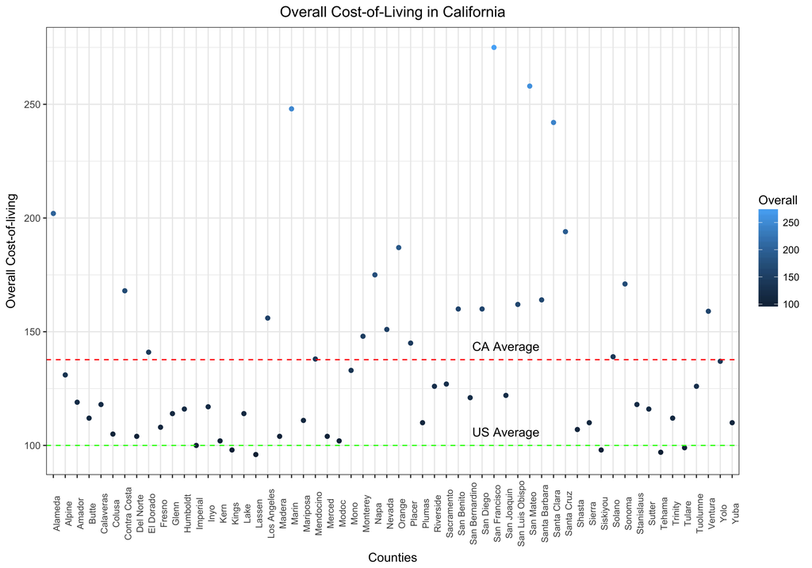

We can esaily find from the figure above that the average cost-of-living is higher than the average of US. Only very few counties' cost-of-living are below the US average. Also, the highest is San Francisco.

*Overall cost-of-living:*

*The total of all the cost of living categories weighted subjectively as follows: housing (30%), food and groceries (15%), transportation (10%), utilities (6%), health care (7%), and miscellaneous expenses such as clothing, services, and entertainment (32%). State and local taxes are not included in any category. Updated: December, 2016*

### Plot2: UnemploymentRate v.s. FutureJobGrowthRate

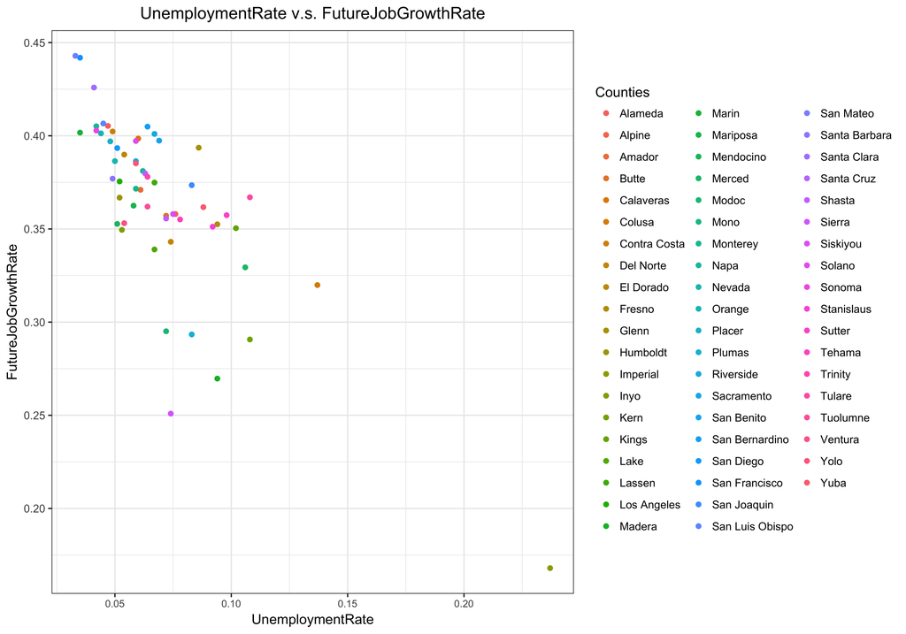

From the figure above we can see that most of counties in CA have a good future for people who want to search job because most results locate in the left upper hand corner(the UnemploymentRate is low and the FutureJobGrowthRate is high).

*UnemploymentRate:*

*The most recent unemployment data for an area. The unemployment rate is expressed as a percentage of the available work force that is not employed. Updated: December, 2016*

*FutureJobGrowthRate:*

*The projected change in job availability over the next ten years based on migration patterns, economic growth, and other factors. A projected decrease in available jobs is represented as a negative number. Updated: December, 2016*

### Plot3: IncomePerCap in California

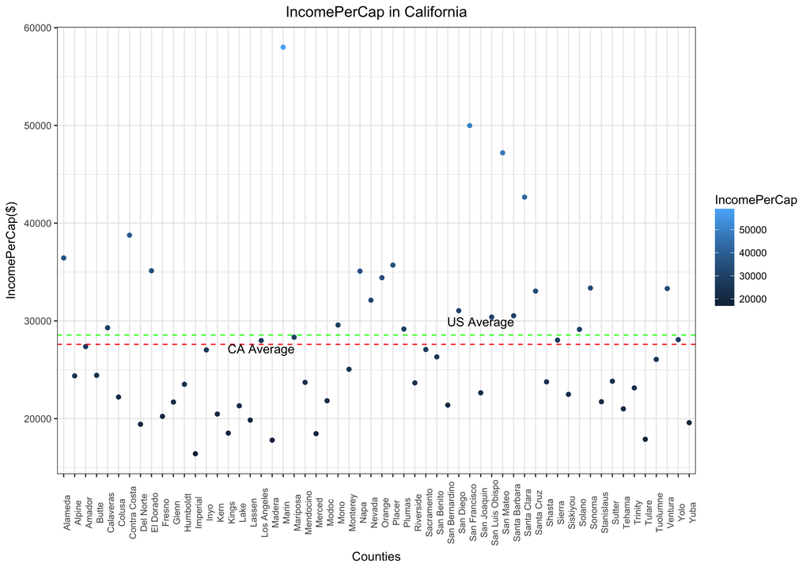

The figure above is about the IncomePerCap in California.

*IncomePerCap:*

*The average income of every resident of a geographic area, including all adults and children. Updated: December, 2016*

## Useful Links

[scraping-data-without-an-api](https://github.com/ropensci/user2016-tutorial/blob/master/03-scraping-data-without-an-api.pdf)

[Extracting data from the web APIs and beyond](https://github.com/ropensci/user2016-tutorial)